# 浅野ゼミナール 夏合宿報告

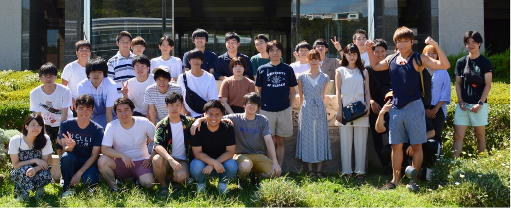

湘南国際村センターにて記念写真

一日目は2年生がビブリオバトルを行い、昨年に増してレベルの高いバトルが行われました。2年生が紹介してくれた本のジャンルも様々で、小説『天気の子』から同性愛者についての小説『モーリス』まで、今の社会問題について深く考えさせられる作品が多々あり、とても充実した時間を過ごすことができました。

湘南国際村センターには18メートルプールがあるので、夜はプールで楽しい時間を過ごしたり、翌日のゼミ論文のリサーチ・デザイン発表に向けて徹夜で仕上げをしたりしていました。

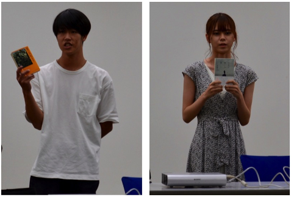

ビブリオ・ウィナーの嶽友君『夏の災厄』と平林さん『やがて海へと届く』

[figure not shown]

3年生と4年生は部屋で発表資料製作中

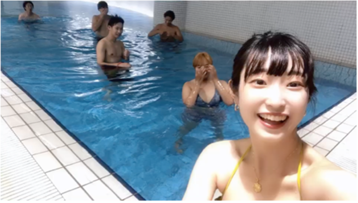

貸し切りプール

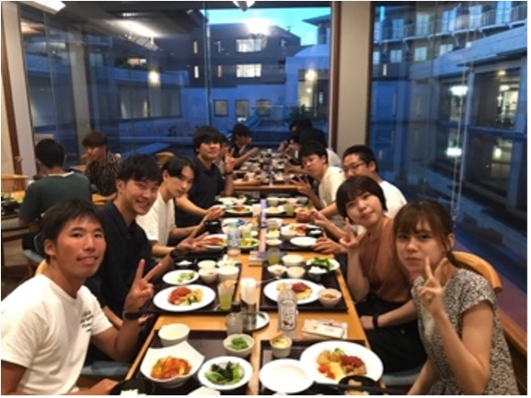

夕食

二日目のゼミ論文のリサーチ・デザインの経過発表では、質疑応答を含め一人持ち時間25分の中、自分では気付かない新たな視点や、想定どおりの分析結果が出ない理由とその改善点などを先生や他のゼミ生から指摘してもらう事により、論文の質を高めることができたと思います。 また、ゼミ論を発表する際、これまで実証政治に触れたことのない2年生にも理解できるくらい丁寧に説明する事により、今まで浅野先生から学んできた実証分析に関する知識を再確認する事が出来ました。このようにゼミ論文の分析手法をじっくりと時間をかけて議論することは通常の授業では経験できない事なので、大変貴重な時間となりました。

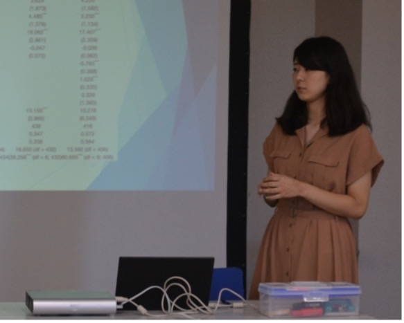

4年の吉川さん

[figure not shown]

4年の宮島君

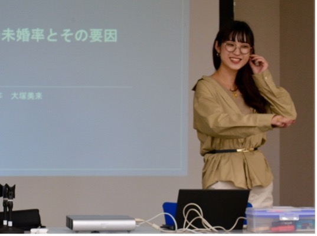

[figure not shown]

4年の滝瀬君

[figure not shown]

夜は打ち上げ！ビンゴ大会で大盛り上がり！

（文責：政経学部 法律政治学科 3年 栗田紘夢）

### ゼミ生の感想

**4年 法律政治学科 吉川有沙**  
今回の夏合宿では緊張感がありながらも、楽しく充実した3日間でした。３・4年生は2日目の朝から論文の途中経過発表がありました。前日の夜には各々が集まり発表資料の改善につとめ、アドバイスし合いました。発表の際には準備の成果がそれぞれ出ており、どの発表もとても素晴らしいものでした。発表者は先生やゼミ生からアドバイスをいただき、それぞれの課題や改善点を知ることができ、今後の論文作成においてとても有意義な時間となりました。 ２年生のビブリオバトルでは、紹介する本についてどう伝えたら皆に読んでみたいと思ってもらえるかを考えながら、一生懸命に発表している姿がとても印象的でした。普段手に取らないようなジャンルの本を知ることができ、とても面白かったです。 私たち４年生にとっては最後の合宿となりました。論文について意見を交換したり、これまでのゼミナールの思い出を話したりと、とても楽しい時間を過ごすことができました。これまで様々な準備をしてくれた幹事の2人をはじめ、先生、ゼミ生に感謝をするとともに、これからのゼミ論執筆に励みたいと思います。

**3年 法律政治学科 大塚美来**  
3年生の私にとって、夏合宿はゼミでの論文作成においてとても重要な過程となる行事でした。2日目に全員の人の前で自分の研究内容を発表するとのことで、前日の夜は狭い2人部屋に学年の皆が集まり協力し合って内容を完成させました。自由時間はプールで遊んだり、サウナに入ったり、それぞれの学年の良さが出た楽しい合宿になりました。幹事のお二方も準備等々大変だったと思いますが、ありがとうございました！

**2年 法律政治学科 長洲雄大**  
ビブリオバトルは初めてだったので、どのように本を紹介するか、どのように伝えるかがとても難しく感じました。そして、他の学生の発表を聞いて、良い所があったので真似していきたいです。先輩方の論文発表では、内容が難しく感じるものもありましたが、日頃研究している事を聞くことができてとてもいい機会でした。